# Examples

## Overview

`sugarglider` provides a ggplot2 extension for producing glyph plots with `geom_glyph_ribbon()` and `geom_glyph_segment()`.

These functions create a ribbon geometry designed to display glyphs based on the combination of `x_major` and `y_major`. For each `x_minor` value, `geom_glyph_ribbon()` displays a y interval defined by `ymin_minor` and `ymax_minor`.

Let’s compare `geom_glyph_ribbon()` and `geom_glyph_segment()`:

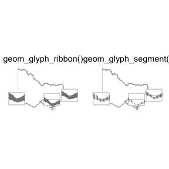

```r
vic_temp <- aus_temp |>
  filter(id %in% c("ASN00026021", "ASN00085291", "ASN00084143"))

p1 <- vic_temp |>
   ggplot(aes(x_major = long, y_major = lat,
              x_minor = month, ymin_minor = tmin, ymax_minor = tmax)) +
  geom_sf(data = abs_ste |> filter(NAME == "Victoria"),
         color = grey(0.7), fill = NA, inherit.aes = FALSE)  +
  # Customize the size of each glyph box using the width and height parameters.
  add_glyph_boxes(width = rel(2.5), height = rel(1.5)) +
  add_ref_lines(width = rel(2.5), height = rel(1.5)) +
  geom_glyph_ribbon(width = rel(2.5), height = rel(1.5)) +
  theme_map() +
  labs(title = "geom_glyph_ribbon()") +
  theme(plot.title = element_text(hjust = 0.5),
        panel.background = element_rect(fill = "white", color = NA),
        plot.background = element_rect(fill = "white", color = NA))

p2 <- vic_temp |>
   ggplot(aes(x_major = long, y_major = lat,
              x_minor = month, y_minor = tmin, yend_minor = tmax)) +
  geom_sf(data = abs_ste |> filter(NAME == "Victoria"),
          color = grey(0.7), fill = NA, inherit.aes = FALSE)  +
  # Customize the size of each glyph box using the width and height parameters.
   add_glyph_boxes(width = rel(2.5), height = rel(1.5)) +
   add_ref_lines(width = rel(2.5), height = rel(1.5)) +
  geom_glyph_segment(width = rel(2.5), height = rel(1.5)) +
  theme_map() +
  labs(title = "geom_glyph_segment()") +
  theme(plot.title = element_text(hjust = 0.5),
        panel.background = element_rect(fill = "white", color = NA),
        plot.background = element_rect(fill = "white", color = NA))

grid.arrange(p1, p2, ncol = 2)
```

## Installation

```r
# Download the development version from GitHub:
devtools::install_github("maliny12/ribbon")
```

## Options

Options allow you to modify the behavior of `sugarglider` to fit the specific needs of your figure. These are all global options that affect every glyph.

| Option | Default | Description |
| --- | --- | --- |
| `x_scale` | `"identity"` | This function scales each set of minor values within a grid cell along the x-dimension. |
| `y_scale` | `"identity"` | This function scales each set of minor values within a grid cell along the y-dimension. |
| `width` | `ggplot2::rel(4)` | Width of the glyph. |
| `height` | `ggplot2::rel(2.5)` | Height of the glyph. |
| `global_rescale` | `TRUE` | Determines whether rescaling is applied globally across all glyphs or individually for each glyph |

## Aesthetics

`sugarglider` provides the same aesthetics for `geom_glyph_ribbon()` and `geom_glyph_segment()` as those available in `geom_ribbon()` or `geom_segment()`, while also introducing additional unique options.

| Option | Default | Description |
| --- | --- | --- |
| `colour` | `"grey50"` | Color for line segments and borders. |
| `linewidth` | `0.5` | Width of the line for borders. |
| `linetype` | `1` | Style of the line for borders. |
| `fill` | `"grey40"` | Color of the interior area of the geometries. |
| `alpha` | `1` | Transparency level of the glyphs. |

## Examples

### Monthly temperature across Australia

The National Oceanica and Atmosphere Administration (NOAA) provides weather data from stations all over Australia. The `aus_temp` dataset contains climate variables such as precipitation, and temperature from 29 different weather stations in the year 2020.

```r
aus_temp
```

```
## # A tibble: 348 × 7
##    id           long   lat month  tmin  tmax     prcp
##    <chr>       <dbl> <dbl> <dbl> <dbl> <dbl>    <dbl>
##  1 ASN00001020  126. -14.1     1  253.  319  164.
##  2 ASN00001020  126. -14.1     2  249.  323. 163.
##  3 ASN00001020  126. -14.1     3  254.  333.  42
##  4 ASN00001020  126. -14.1     4  244.  341.  21.6
##  5 ASN00001020  126. -14.1     5  220.  332.   0
##  6 ASN00001020  126. -14.1     6  202.  311.  11.2
##  7 ASN00001020  126. -14.1     7  154.  292.   0
##  8 ASN00001020  126. -14.1     8  186.  326.   0.0690
##  9 ASN00001020  126. -14.1     9  228.  337.   2.73
## 10 ASN00001020  126. -14.1    10  256.  341.  12
## # ℹ 338 more rows
```

With the default rescaling parameters, this is the resulting geom segment glyph along with a geom_point to help illustrate the station location that each segment glyph corresponds to.

The default `identity` scaling function is applied to all applied to each set of minor values within a grid cell. It centers the glyph both vertically and horizontally based on the station’s location and adjusts the minor axes to fit within the interval [-1, 1]. This ensures the glyph fits the desired width and height.

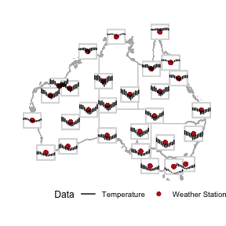

```r
aus_temp |>
  ggplot(aes(
    x_major = long,
    y_major = lat,
    x_minor = month,
    y_minor = tmin,
    yend_minor = tmax)) +
  geom_sf(data = abs_ste, color = grey(0.7),
          fill = NA, inherit.aes = FALSE) +
  coord_sf(xlim = c(110,155)) +
  # Add glyph box to each glyph
  add_glyph_boxes(
    width = 4,
    height = 3) +
  geom_point(aes(x = long, y = lat,
                 color = "Weather Station")) +
  geom_glyph_segment(
    # Customize the size of each glyph box using the width and height parameters.
    width = 4,
    height = 3,
    aes(color = "Temperature")) +
  ggthemes::theme_map() +
  scale_color_manual(
    values = c("Weather Station" = "firebrick",
               "Temperature" = "black")) +
  labs(color = "Data")  +
  theme(legend.position.inside = c(.2,0),
        legend.direction = "horizontal")
```

All previous examples have been made with global rescaling enabled (default), resulting in glyphs being sized differently according to their values relative to each other. Turning off global rescaling allows each glyph to be rescaled based on its own individual values, producing more evenly sized glyphs.

Local Rescale: With global_rescale = FALSE, the length of each line segment is based on the local temperature range within each region, highlighting regional differences.

Global Rescale: With global_rescale = TRUE, the length of each line segment is based on the global temperature range, ensuring consistency in glyph size across regions.

The following plot compares the two rescaling options.

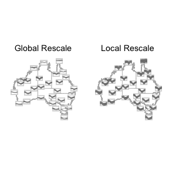

```r
# Global rescale
p1 <- aus_temp |>
  ggplot(aes(
    x_major = long,
    y_major = lat,
    x_minor = month,
    y_minor = tmin,
    yend_minor = tmax)) +
  geom_sf(data = abs_ste, color = grey(0.7),
          fill = NA, inherit.aes = FALSE) +
  coord_sf(xlim = c(110,155)) +
  # Add glyph box to each glyph
  add_glyph_boxes() +
  # Add reference lines to each glyph
  add_ref_lines() +
  geom_glyph_segment(global_rescale = TRUE) +
  ggthemes::theme_map() +
  labs(title = "Global Rescale") +
  theme(plot.title = element_text(hjust = 0.5),
        panel.background = element_rect(fill = "white", color = NA),
        plot.background = element_rect(fill = "white", color = NA))

# Local Rescale
p2 <- aus_temp |>
  ggplot(aes(
    x_major = long,
    y_major = lat,
    x_minor = month,
    y_minor = tmin,
    yend_minor = tmax)) +
  geom_sf(data = abs_ste, color = grey(0.7),
          fill = NA, inherit.aes = FALSE) +
  coord_sf(xlim = c(110,155)) +
  # Add glyph box to each glyph
  add_glyph_boxes() +
  # Add reference lines to each glyph
  add_ref_lines() +
  geom_glyph_segment(global_rescale = FALSE) +
  ggthemes::theme_map() +
  labs(title = "Local Rescale") +
  theme(plot.title = element_text(hjust = 0.5),
        panel.background = element_rect(fill = "white", color = NA),
        plot.background = element_rect(fill = "white", color = NA))

grid.arrange(p1, p2, ncol = 2)
```

#### Highlighting Temperature Changes with Color-Coded Glyph

Building on the temperature analysis, this section maps precipitation across Australia using glyphs. Average rainfall is calculated for each region and visualized with `geom_glyph_ribbon()`. The glyphs are color-coded to show different rainfall levels. Reference lines and glyph boxes, similar to the previous section, enhance readability and provide a clear comparison of precipitation patterns across the country.

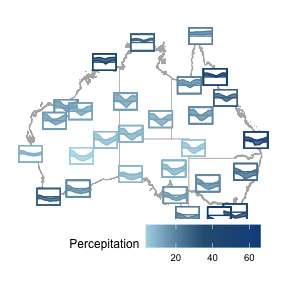

```r
prcp <- aus_temp |>
   group_by(id) |>
   mutate(prcp = mean(prcp, na.rm = TRUE)) |>
   ggplot(aes(x_major = long, y_major = lat, x_minor = month,
              ymin_minor = tmin, ymax_minor = tmax,
              fill = prcp, color = prcp)) +
  geom_sf(data = abs_ste, color = grey(0.7), fill = NA,
          inherit.aes = FALSE)  +
   add_glyph_boxes() +
   add_ref_lines() +
   geom_glyph_ribbon() +
   coord_sf(xlim = c(112,155)) +
  theme_map() +
  theme(legend.position.inside = c(.2,0),
        legend.direction = "horizontal",
        panel.background = element_rect(fill = "white", color = NA),
        plot.background = element_rect(fill = "white", color = NA)) +
  scale_fill_gradientn(colors = c("#ADD8E6", "#2b5e82", "dodgerblue4")) +
  scale_color_gradientn(colors = c( "#ADD8E6", "#2b5e82", "dodgerblue4")) +
  labs(fill = "Percepitation", color = "Percepitation")


grid.arrange(prcp, ncol = 1)
```

Say you want to compares temperature data across different years for selected regions in Victoria. Using `geom_glyph_ribbon()`, the visualization shows how temperatures have changed over time, with each year highlighted in different colors for easy comparison. Reference lines and glyph boxes help clarify the data, making it simple to spot trends and patterns across the years.

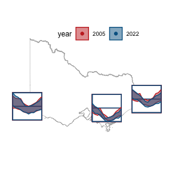

```r
fact <- historical_temp |>
  filter(id %in% c("ASN00026021", "ASN00085291", "ASN00084143")) |>
   ggplot(aes(color = factor(year), fill = factor(year),
              group = interaction(year,id),
              x_major = long, y_major = lat,
              x_minor = month, ymin_minor = tmin,
              ymax_minor = tmax)) +
  geom_sf(data = abs_ste |> filter(NAME == "Victoria"),
           fill = NA, color = grey(0.7),
          inherit.aes = FALSE)  +
   add_glyph_boxes(width = rel(2),
                   height = rel(1.5)) +
   add_ref_lines(width = rel(2),
                 height = rel(1.5)) +
   geom_glyph_ribbon(alpha = 0.5,
                     width = rel(2),
                     height = rel(1.5)) +
  labs(x = "Longitude", y = "Latitude",
       color = "year", fill = "year") +
  theme_map() +
  theme(legend.position.inside = c(.3,0.9),
        legend.direction = "horizontal",
        panel.background = element_rect(fill = "white", color = NA),
        plot.background = element_rect(fill = "white", color = NA)) +
  scale_colour_wsj("colors6") +
  scale_fill_wsj("colors6")


grid.arrange(fact, ncol = 1)
```

#### Integrating Glyph Legends

In this example, a map of Australia is created with geom_glyph_ribbon() to display temperature data. The legend is integrated directly into the plot using add_glyph_legend(), providing a clear reference for interpreting the glyphs without cluttering the map. This approach ensures that the visualization remains both informative and visually clean.

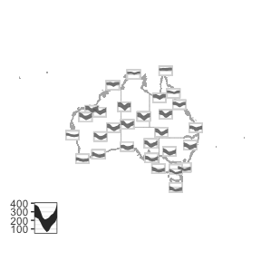

```r
legend <- aus_temp |>
   ggplot(aes(x_major = long, y_major = lat,
              x_minor = month, ymin_minor = tmin,
              ymax_minor = tmax)) +
  geom_sf(data = abs_ste ,
           fill = NA, color = grey(0.7),
           inherit.aes = FALSE)  +
  add_glyph_boxes() +
  add_ref_lines() +
  add_glyph_legend() +
  geom_glyph_ribbon() +
  theme(legend.position.inside = c(.3,0.9),
        legend.direction = "horizontal",
        panel.background = element_rect(fill = "white", color = NA),
        plot.background = element_rect(fill = "white", color = NA)) +
  theme_map()


grid.arrange(legend, ncol = 1)
```

#### Observations and Insights

Geom Segment Glyphs offer unique insights into seasonal temperature trends across Australia. Turning off global rescaling shows that most stations generally followed the same curvature trends relative to their lowest temperatures. However factoring in global rescaling, coastal regions show much less total variation in temperature.